# Learning Lab 2 Case Study: Feature Engineering

Michael Daley

July 14, 2022

This case study is similar to the first, but it differs in three key ways:

1. We use a very different data set, one from *online science classes* that involves a variety of variables types
2. We focus on *feature engineering*, a key step in which we prepare variables for inclusion in our machine learning models
3. We use resampling to evaluate the effectiveness of the feature engineering steps

Feature engineering is a rich topic in machine learning research, including in the learning analytics and educational data mining communities.

Consider research on online learning and the work of Li et al. (2020) and Rodriguez et al. (2021). In these two studies, digital *log-trace data*, data generated through users’ interactions with digital technologies, was used to study elements of the theoretical frame of *self-regulated learning* and how it related to students’ achievement. Notably, the authors took several steps to prepare the data so that it could be validly interpreted as measures of students’ self-regulated learning. In short, we need to process the data from contexts such as online classes to use them in analyses. Citations and links to these papers follow.

> Li, Q., Baker, R., & Warschauer, M. (2020). Using clickstream data to measure, understand, and support self-regulated learning in online courses. The Internet and Higher Education, 45, 100727. https://github.com/laser-institute/essential-readings/blob/main/machine-learning/ml-lab-2/li-et-al-2020-ihe.pdf

> Rodriguez, F., Lee, H. R., Rutherford, T., Fischer, C., Potma, E., & Warschauer, M. (2021, April). Using clickstream data mining techniques to understand and support first-generation college students in an online chemistry course. In LAK21: 11th International Learning Analytics and Knowledge Conference (pp. 313-322). https://github.com/laser-institute/essential-readings/blob/main/machine-learning/ml-lab-2/rodriguez-et-al-2021-lak.pdf

The same is true here in the context of machine learning. In a different context, the work of Gobert et al. (2013) is a great example of using data from educational simulations. Salmeron-Majadas provides an example of feature engineering using mouse-click data. Last, we note that there are methods that intended to automated the process of feature engineering (Bosch et al., 2021), though such processes are not necessarily interpretable and they usually require some degree of tailoring to your particular context.

> Gobert, J. D., Sao Pedro, M., Raziuddin, J., & Baker, R. S. (2013). From log files to assessment metrics: Measuring students’ science inquiry skills using educational data mining. Journal of the Learning Sciences, 22(4), 521-563. https://github.com/laser-institute/essential-readings/blob/main/machine-learning/ml-lab-3/gobert-et-al-2013-jls.pdf

> Salmeron-Majadas, S., Baker, R. S., Santos, O. C., & Boticario, J. G. (2018). A machine learning approach to leverage individual keyboard and mouse interaction behavior from multiple users in real-world learning scenarios. IEEE Access, 6, 39154-39179. https://ieeexplore.ieee.org/iel7/6287639/8274985/08416736.pdf

> Bosch, N. (2021). AutoML Feature Engineering for Student Modeling Yields High Accuracy, but Limited Interpretability. Journal of Educational Data Mining, 13(2), 55-79. https://github.com/laser-institute/essential-readings/blob/main/machine-learning/ml-lab-3/bosch-et-al-2021-jedm.pdf

Our driving question for this case study is: How much do new predictors improve the prediction quality?

We use a data set of many online classes to answer this question. To answer it, we will engage in several feature engineering steps.

## Step 0: Loading and setting up

Like in the first learning lab, we’ll first load several packages.

```r
library(tidyverse)
library(tidymodels)
```

Like in the code-along for the overview presentation, let’s take a look at the data and do some processing of it.

```r
d <- read_csv("data/data-to-model-no-gradebook.csv")
d <- select(d, -time_spent) # this is another outcome, so we'll cut this here

gb <- read_csv("data/data-to-model-gradebook.csv")
```

We mentioned that this lab is premised on the need to improve on an earlier model. Indeed, an earlier version of this model without feature engineering achieved predictive accuracy of an RMSE of approximately 13 (see more [here](https://datascienceineducation.com/c14.html)). Predicting students’ passing (or not passing) the course with around 75% accuracy. We think we can do better – the aim of this learning lab is to do just that.

As a bit more background, the online science classes we explore in this chapter were designed and taught by instructors through a state-wide online course provider designed to supplement—but not replace—students’ enrollment in their local school. For example, students may have chosen to enroll in an online physics class because one was not offered at their school. The data were originally collected for a research study, which utilized a number of different data sources to understand students’ course-related motivation. These datasets included:

1. A self-report survey assessing three aspects of students’ motivation
2. Log-trace data, such as data output from the learning management system (LMS)
3. Discussion board data
4. Academic achievement data provided in a gradebook (for the first 20 assignments students’ completed)

*Data sources 1-3 are already joined together in the data frame we named `d` above*

*Data source 4 - the gradebook data - is separate, in the data frame we named `gb`.*

Take a look at the two data frames by running the two chunks below.

```r
d
```

```
## # A tibble: 546 × 15
##    student_id course_id     gender enrollment_reas… enrollment_stat… final_grade
##         <dbl> <chr>         <chr>  <chr>            <chr>                  <dbl>
##  1      60186 AnPhA-S116-01 M      Course Unavaila… Approved/Enroll…        86.3
##  2      66693 AnPhA-S116-01 M      Course Unavaila… Approved/Enroll…        93.8
##  3      66811 AnPhA-S116-01 F      Course Unavaila… Approved/Enroll…        91.2
##  4      70532 AnPhA-S116-01 F      Learning Prefer… Approved/Enroll…        93.6
##  5      77010 AnPhA-S116-01 F      Learning Prefer… Approved/Enroll…        73.2
##  6      85249 AnPhA-S116-01 F      Course Unavaila… Approved/Enroll…        86.9
##  7      85411 AnPhA-S116-01 F      Scheduling Conf… Approved/Enroll…        90.9
##  8      85583 AnPhA-S116-01 F      Scheduling Conf… Approved/Enroll…        91.7
##  9      85866 AnPhA-S116-01 F      Learning Prefer… Approved/Enroll…        75.1
## 10      85970 AnPhA-S116-01 F      Course Unavaila… Approved/Enroll…        81.6
## # … with 536 more rows, and 9 more variables: subject <chr>, semester <chr>,
## #   section <chr>, int <dbl>, uv <dbl>, percomp <dbl>, tv <dbl>,
## #   sum_discussion_posts <dbl>, sum_n_words <dbl>
```

```r
gb
```

```
## # A tibble: 14,340 × 12
##    course_id     student_id gradebook_item          item_position gradebook_type
##    <chr>              <dbl> <chr>                           <dbl> <chr>
##  1 FrScA-S216-02      43146 0-1.1: Intro Assignmen…            10 N
##  2 FrScA-S216-02      43146 0-1.2: Intro Assignmen…            11 N
##  3 FrScA-S216-02      43146 0-1.3: Intro Assignmen…            12 N
##  4 FrScA-S216-02      43146 1-1.1: Lesson 1-1 Grap…            13 N
##  5 FrScA-S216-02      43146 1-2.1: Explore a Caree…            14 N
##  6 FrScA-S216-02      43146 1-2.2: Explore a Caree…            15 N
##  7 FrScA-S216-02      43146 PROGRESS CHECK 1 @ 02-…            16 P
##  8 FrScA-S216-02      43146 1-2.3: Lesson 1-2 Grap…            17 N
##  9 FrScA-S216-02      43146 Unit 1 Assessment                  18 N
## 10 FrScA-S216-02      43146 2-1.1: Crime Scene DB …            19 N
## # … with 14,330 more rows, and 7 more variables: gradebook_date <chr>,
## #   grade_category <chr>, status <lgl>, points_earned <dbl>,
## #   points_attempted <dbl>, points_possible <dbl>, last_access_date <time>
```

You’ll notice the data have different dimensions. We’ll have to take some steps to further process the gradebook data. In doing so, we’ll engineer some features. Let’s take a closer look at the gradebook data.

```r
gb %>%
    glimpse()
```

```
## Rows: 14,340
## Columns: 12
## $ course_id        <chr> "FrScA-S216-02", "FrScA-S216-02", "FrScA-S216-02", "F…
## $ student_id       <dbl> 43146, 43146, 43146, 43146, 43146, 43146, 43146, 4314…
## $ gradebook_item   <chr> "0-1.1: Intro Assignment - Send a Message to Your Ins…
## $ item_position    <dbl> 10, 11, 12, 13, 14, 15, 16, 17, 18, 19, 20, 21, 22, 2…
## $ gradebook_type   <chr> "N", "N", "N", "N", "N", "N", "P", "N", "N", "N", "N"…
## $ gradebook_date   <chr> "31:28.9", "47:10.5", "01:26.5", "33:11.5", "25:33.2"…
## $ grade_category   <chr> "Hw", "Hw", "Hw", "Hw", "Hw", "Hw", NA, "Hw", "Qz", "…
## $ status           <lgl> NA, NA, NA, NA, NA, NA, NA, NA, NA, NA, NA, NA, NA, N…
## $ points_earned    <dbl> 5, 5, 5, 5, 12, 5, 37, 5, 18, 5, 5, 10, 26, 5, 10, 10…
## $ points_attempted <dbl> 0, 0, 0, 0, 0, 0, 37, 0, 0, 0, 0, 0, 0, 0, 0, 0, 0, 1…
## $ points_possible  <dbl> 5, 5, 5, 5, 12, 5, 37, 5, 20, 5, 5, 10, 28, 5, 10, 10…
## $ last_access_date <time> 00:56:00, 00:56:00, 00:56:00, 00:56:00, 00:56:00, 00…
```

#### Your Turn ⤵

You may also want to take a look *through* the data with the `View()` function; try that out below (asking for help or searching the Internet for help as needed!).

```r
view(gb)
```

Let’s first consider what these variables are, focusing just on some key variables:

- `course_id`: an identifier for the course
- `student_id`: an identifier for the student
- `gradebook_item`: the name of the gradebook entry/assignment
- `item_position`: the position of the gradebook item in the gradebook; differs between students
- `grade_category`: `Hw` (homework), `Qz` (quiz or test), or `NA` (not classified)
- `points_earned`: the number of points student earned
- `points_possible`: the number of points possible to earn

What are some *features* we could create based on these variables? And how might we create them?

#### Your Turn ⤵

Add a few ideas below before proceeding:

- distance from class mean for points_earned
- percentage grade

```r
gb
```

```
## # A tibble: 14,340 × 12
##    course_id     student_id gradebook_item          item_position gradebook_type
##    <chr>              <dbl> <chr>                           <dbl> <chr>
##  1 FrScA-S216-02      43146 0-1.1: Intro Assignmen…            10 N
##  2 FrScA-S216-02      43146 0-1.2: Intro Assignmen…            11 N
##  3 FrScA-S216-02      43146 0-1.3: Intro Assignmen…            12 N
##  4 FrScA-S216-02      43146 1-1.1: Lesson 1-1 Grap…            13 N
##  5 FrScA-S216-02      43146 1-2.1: Explore a Caree…            14 N
##  6 FrScA-S216-02      43146 1-2.2: Explore a Caree…            15 N
##  7 FrScA-S216-02      43146 PROGRESS CHECK 1 @ 02-…            16 P
##  8 FrScA-S216-02      43146 1-2.3: Lesson 1-2 Grap…            17 N
##  9 FrScA-S216-02      43146 Unit 1 Assessment                  18 N
## 10 FrScA-S216-02      43146 2-1.1: Crime Scene DB …            19 N
## # … with 14,330 more rows, and 7 more variables: gradebook_date <chr>,
## #   grade_category <chr>, status <lgl>, points_earned <dbl>,
## #   points_attempted <dbl>, points_possible <dbl>, last_access_date <time>
```

Let’s get to feature engineering. First, we’ll have to *group* our data by course and student ID.

```r
gb <- gb %>%
    group_by(course_id, student_id)
```

#### Your Turn ⤵

Next, let’s create a variable with the percent of points earned (points earned divided by points possible). To do so, add to the `mutate()` function below. Create a new variable called `percent_earned`. You can read more about mutate [here](https://r4ds.had.co.nz/transform.html)

```r
gb <- gb %>%
    mutate(percent_earned = points_earned/points_possible)
```

Finally, let’s create three features from the gradebook data:

- The overall percent of points earned (*across* all assignments)
- The variability (in standard deviation units) in the percent earned (*between* assignments)
- The number of assignments for which students earned 100% of the possible points

You can probably imagine others; you’re welcome to explore adding those, too.

We’ll use *summarize* to do this, as below:

```r
gb <- gb %>%
    summarize(overall_percent_earned = sum(points_earned, na.rm = TRUE) / sum(points_possible, na.rm = TRUE),
              variability_percent_earned = sd(percent_earned, na.rm = TRUE),
              n_with_100_pct = sum(percent_earned == 1, na.rm = TRUE)) %>%
    select(student_id, course_id, overall_percent_earned, variability_percent_earned, n_with_100_pct) # selecting just the variables we'll use
```

We have one last step before we can get to modeling (`gb`) - joining this data with all of the other data (`d`).

```r
d <- d %>%
    left_join(gb)
```

#### Your Turn ⤵

Let’s talk a look at the joined data to make sure everything is looking as we intend it to. Inspect the data using the code chunk below:

```r
view(d)
```

## Step 1. Split data

Next, we’ll split the data, just like before. We’ll set the seed again to ensure that we obtain the same results (when running the analysis again and between analysts at the LASER Institute). We use an 80% split again; how will you “spend” your data? You can change this number if you wish, but consider how much data you have to “spend” for both training and testing.

```r
set.seed(20220712)

train_test_split <- initial_split(d, prop = .80)

data_train <- training(train_test_split)
```

Here’s a key difference! Pay careful attention to this next line of code, which sets the groundwork for *k*-folds cross-validation. Note that in the function below (run `?vfold_cv` to see more), the letter *v* is used instead of *k*, though they share a meaning, as the documentation notes).

```r
kfcv <- vfold_cv(data_train) # this differentiates this from what we did before
# before, we simple used data_train to fit our model
kfcv
```

```
## #  10-fold cross-validation
## # A tibble: 10 × 2
##    splits           id
##    <list>           <chr>
##  1 <split [392/44]> Fold01
##  2 <split [392/44]> Fold02
##  3 <split [392/44]> Fold03
##  4 <split [392/44]> Fold04
##  5 <split [392/44]> Fold05
##  6 <split [392/44]> Fold06
##  7 <split [393/43]> Fold07
##  8 <split [393/43]> Fold08
##  9 <split [393/43]> Fold09
## 10 <split [393/43]> Fold10
```

#### Your Turn ⤵

Above, we split the data into 10 different folds. Change the number of folds from 10 to 20 by changing the value of v; 10 is simply the default. For help, run `?vfold_cv` to get a hint.

```r
kfcv <- vfold_cv(data_train, v=20) # this differentiates this from what we did before
# before, we simple used data_train to fit our model
kfcv
```

```
## #  20-fold cross-validation
## # A tibble: 20 × 2
##    splits           id
##    <list>           <chr>
##  1 <split [414/22]> Fold01
##  2 <split [414/22]> Fold02
##  3 <split [414/22]> Fold03
##  4 <split [414/22]> Fold04
##  5 <split [414/22]> Fold05
##  6 <split [414/22]> Fold06
##  7 <split [414/22]> Fold07
##  8 <split [414/22]> Fold08
##  9 <split [414/22]> Fold09
## 10 <split [414/22]> Fold10
## 11 <split [414/22]> Fold11
## 12 <split [414/22]> Fold12
## 13 <split [414/22]> Fold13
## 14 <split [414/22]> Fold14
## 15 <split [414/22]> Fold15
## 16 <split [414/22]> Fold16
## 17 <split [415/21]> Fold17
## 18 <split [415/21]> Fold18
## 19 <split [415/21]> Fold19
## 20 <split [415/21]> Fold20
```

```r
?vfold_cv
```

## Step 2: Engineer features and write down the recipe

Here, we’ll carry out several feature engineering steps.

#### Your Turn ⤵

Read about [possible steps](https://www.tmwr.org/recipes.html) and see more about how the following five feature engineering steps below work. Like in the first learning lab, this is the step in which we set the recipe.

- `step_normalize(all_numeric_predictors())`
- `step_nzv(all_predictors())`
- `step_novel(all_nominal_predictors())`
- `step_dummy(all_nominal_predictors())`
- `step_impute_knn(all_predictors(), all_outcomes())`

```r
my_rec <- recipe(final_grade ~ ., data = data_train) %>%
    step_normalize(all_numeric_predictors()) %>% # standardizes numeric variables
    step_nzv(all_predictors()) %>% # remove predictors with a "near-zero variance"
    step_novel(all_nominal_predictors()) %>% # add a musing label for factors
    step_dummy(all_nominal_predictors()) %>%  # dummy code all factor variables
    step_impute_knn(all_predictors()) # impute missing data for all predictor variables
```

## Step 3: Specify the model and workflow

Next, we specify the model and workflow, using the same engine *but a different engine and mode*, here, regression for a *continuous outcome*. Specifically, we use:

- using the `linear_reg()` function to set the *model*
- using `set_engine("glm")` to set the *engine*
- finally, using `set_mode("regression"))`

```r
# specify model
my_mod <-
    linear_reg() %>%
    set_engine("glm") %>%
    set_mode("regression")
```

Last, we’ll put the pieces together - the model and recipe - in a workflow.

```r
# specify workflow
my_wf <-
    workflow() %>%
    add_model(my_mod) %>%
    add_recipe(my_rec)
```

## Step 4: Fit model

Note that here we use the `kfcv` data. We’ll run that in the next chunk.

We can ignore the warnings and messages we see.

```r
fitted_model_resamples <- fit_resamples(my_wf, resamples = kfcv,
                              control = control_grid(save_pred = TRUE)) # this allows us to inspect the predictions
```

[output not shown]

[output not shown]

[output not shown]

[output not shown]

[output not shown]

[output not shown]

[output not shown]

[output not shown]

[output not shown]

[output not shown]

[output not shown]

[output not shown]

[output not shown]

[output not shown]

[output not shown]

[output not shown]

[output not shown]

[output not shown]

[output not shown]

[output not shown]

[output not shown]

[output not shown]

[output not shown]

[output not shown]

[output not shown]

[output not shown]

[output not shown]

[output not shown]

[output not shown]

[output not shown]

[output not shown]

[output not shown]

[output not shown]

[output not shown]

[output not shown]

[output not shown]

[output not shown]

[output not shown]

[output not shown]

[output not shown]

## Step 5: Interpret accuracy

What did we get as output? Let’s take a look at the metrics. This is critical to understanding how and why we use k-folds cross validation. Each of the rows below represents the accuracy (in the `.estimate` column) for each of the 20 folds that we used to train our model; our model was fit 20 times, and accuracy was calculated separately for each of these times. Next, we’ll summarize these.

Recall our definition of the Root Mean Squared Error (RMSE) - it is the *square root* of the mean of the squared error, or difference between the predicted and known *y* variables (here, students’ final grade). Since this is the square root of a statistic that is squared, its interpretation can be considerably simplified: **RMSE can be interpreted as the average error, or difference between the predicted and known *y* variables (here, students’ final grade)**. This, along with the Mean Squared Error (MSE), are the most common metrics of predictive accuracy for a numeric outcome such as students’ final grade. See more about fit metrics for numeric/continuous outcomes (those utilized in a *regression* mode) [here](https://bradleyboehmke.github.io/HOML/process.html#regression-models). The goal is to minimize both the RMSE and MSE.

Note that the common R-squared measure (`rsq` in the output) can also be interpreted. Though helpful descriptively, it has less useful as a measure of the predictive effectiveness of a trained model, and it should generally not be used to select between competing model specifications.

```r
fitted_model_resamples %>%
    unnest(.metrics) %>%
    filter(.metric == "rmse") # we also get another metric, the RSQ; we focus just on RMSE for nwo
```

```
## # A tibble: 20 × 8
##    splits           id     .metric .estimator .estimate .config         .notes
##    <list>           <chr>  <chr>   <chr>          <dbl> <chr>           <list>
##  1 <split [414/22]> Fold01 rmse    standard        8.58 Preprocessor1_… <tibble>
##  2 <split [414/22]> Fold02 rmse    standard        5.64 Preprocessor1_… <tibble>
##  3 <split [414/22]> Fold03 rmse    standard       13.3  Preprocessor1_… <tibble>
##  4 <split [414/22]> Fold04 rmse    standard        6.22 Preprocessor1_… <tibble>
##  5 <split [414/22]> Fold05 rmse    standard        9.08 Preprocessor1_… <tibble>
##  6 <split [414/22]> Fold06 rmse    standard        6.84 Preprocessor1_… <tibble>
##  7 <split [414/22]> Fold07 rmse    standard       13.5  Preprocessor1_… <tibble>
##  8 <split [414/22]> Fold08 rmse    standard        9.17 Preprocessor1_… <tibble>
##  9 <split [414/22]> Fold09 rmse    standard        8.45 Preprocessor1_… <tibble>
## 10 <split [414/22]> Fold10 rmse    standard        6.94 Preprocessor1_… <tibble>
## 11 <split [414/22]> Fold11 rmse    standard        9.92 Preprocessor1_… <tibble>
## 12 <split [414/22]> Fold12 rmse    standard        7.68 Preprocessor1_… <tibble>
## 13 <split [414/22]> Fold13 rmse    standard        8.16 Preprocessor1_… <tibble>
## 14 <split [414/22]> Fold14 rmse    standard        5.97 Preprocessor1_… <tibble>
## 15 <split [414/22]> Fold15 rmse    standard       13.1  Preprocessor1_… <tibble>
## 16 <split [414/22]> Fold16 rmse    standard       10.8  Preprocessor1_… <tibble>
## 17 <split [415/21]> Fold17 rmse    standard        8.89 Preprocessor1_… <tibble>
## 18 <split [415/21]> Fold18 rmse    standard        6.13 Preprocessor1_… <tibble>
## 19 <split [415/21]> Fold19 rmse    standard       16.7  Preprocessor1_… <tibble>
## 20 <split [415/21]> Fold20 rmse    standard        6.92 Preprocessor1_… <tibble>
## # … with 1 more variable: .predictions <list>
```

```r
# fit stats
fitted_model_resamples %>%
    collect_metrics()
```

```
## # A tibble: 2 × 6
##   .metric .estimator  mean     n std_err .config
##   <chr>   <chr>      <dbl> <int>   <dbl> <chr>
## 1 rmse    standard   9.10     20  0.672  Preprocessor1_Model1
## 2 rsq     standard   0.756    20  0.0402 Preprocessor1_Model1
```

We can imagine trying out many different sets of features (engineered in different ways). So long as we evaluate the accuracy using the resampling method used above, we can repeat this process as needed. Then, we can carry out a process like that in the first learning lab - fitting the model not using the different *folds* obtained through the `kfcv` function, but rather using the **entire training data set**.

```r
fitted_model <- fit(my_wf, data_train)
```

```r
final_fit <- last_fit(fitted_model, train_test_split)
```

```
## ! train/test split: preprocessor 1/1: skipping variable with zero or non-finite range.
```

```
## ! train/test split: preprocessor 1/1, model 1/1 (predictions): skipping variable with zero or non-finite range., prediction from a rank...
```

```r
collect_metrics(final_fit)
```

```
## # A tibble: 2 × 4
##   .metric .estimator .estimate .config
##   <chr>   <chr>          <dbl> <chr>
## 1 rmse    standard       8.90  Preprocessor1_Model1
## 2 rsq     standard       0.817 Preprocessor1_Model1
```

Last, we can plot the predicted versus known *y* variables to gain a graphical sense for how the model performed:

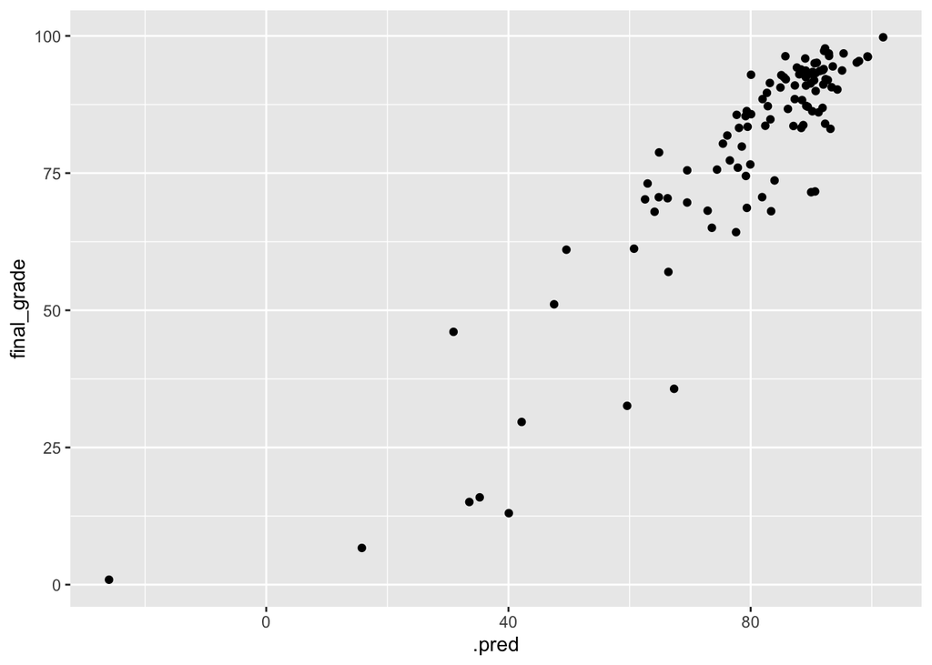

```r
collect_predictions(final_fit) %>%
    ggplot(aes(x = .pred, y = final_grade)) +
    geom_point()
```

Consider making a modification to the above plot (small or large) using ggplot2.

### 🧶 Knit & Check ✅

Congratulations - you’ve completed this case study! Consider moving on to the badge activity next.